# Project Q1

Question: correlation between price and sales.

Reading data:

```r
sales_data_df <- read.csv(file = '~/Desktop/MDSA/602/Project/summer-products-with-rating-and-performance_2020-08.csv')
```

```r
head(sales_data_df)
```

|  | title | title_orig | price | retail_price | currency_buyer | units_sold | uses_ad_boosts | rating | rating_count | rating_five_count | rating_four_count | rating_three_count | rating_two_count | rating_one_count | badges_count | badge_local_product | badge_product_quality | badge_fast_shipping | tags | product_color | product_variation_size_id | product_variation_inventory | shipping_option_name | shipping_option_price | shipping_is_express | countries_shipped_to | inventory_total | has_urgency_banner | urgency_text | … |
| --- | --- | --- | --- | --- | --- | --- | --- | --- | --- | --- | --- | --- | --- | --- | --- | --- | --- | --- | --- | --- | --- | --- | --- | --- | --- | --- | --- | --- | --- | --- |
| 1 | 2020 Summer Vintage Flamingo Print Pajamas Set Casual Loose T Shirt Top And Elastic Shorts Women Sleepwear Night Wear Loungewear Sets | 2020 Summer Vintage Flamingo Print Pajamas Set Casual Loose T Shirt Top And Elastic Shorts Women Sleepwear Night Wear Loungewear Sets | 16.00 | 14 | EUR | 100 | 0 | 3.76 | 54 | 26 | 8 | 10 | 1 | 9 | 0 | 0 | 0 | 0 | Summer,Fashion,womenunderwearsuit,printedpajamasset,womencasualshort,Women's Fashion,flamingo,loungewearset,Casual,Shirt,casualsleepwear,Shorts,flamingotshirt,Elastic,Vintage,Tops,tshirtandshortsset,W… | white | M | 50 | Livraison standard | 4 | 0 | 34 | 50 | 1 | Quantité limitée ! | … |
| 2 | SSHOUSE Summer Casual Sleeveless Soirée Party Soirée sans manches Vêtements de plage sexy Mini robe femme wshC1612242400387A21 | Women's Casual Summer Sleeveless Sexy Mini Dress | 8.00 | 22 | EUR | 20000 | 1 | 3.45 | 6135 | 2269 | 1027 | 1118 | 644 | 1077 | 0 | 0 | 0 | 0 | Mini,womens dresses,Summer,Patchwork,fashion dress,Dress,Mini dress,Women's Fashion,Women S Clothing,backless,party,summer dresses,sleeveless,sexy,Casual | green | XS | 50 | Livraison standard | 2 | 0 | 41 | 50 | 1 | Quantité limitée ! | … |
| 3 | 2020 Nouvelle Arrivée Femmes Printemps et Été Plage Porter Longue Mince Cardigan Ouvert Avant Kimono Vert Feuille Imprimé En Mousseline de Soie Cardigan S-5XL | 2020 New Arrival Women Spring and Summer Beach Wear Long Thin Cardigan Open Front Kimono Green Leaf Printed Chiffon Cardigan S-5XL | 8.00 | 43 | EUR | 100 | 0 | 3.57 | 14 | 5 | 4 | 2 | 0 | 3 | 0 | 0 | 0 | 0 | Summer,cardigan,women beachwear,chiffon,Sexy women,Coat,summercardigan,openfront,short sleeves,Swimsuit,Women's Fashion,leaf,Green,printed,Spring,longcardigan,Women,Beach,kimono | leopardprint | XS | 1 | Livraison standard | 3 | 0 | 36 | 50 | 1 | Quantité limitée ! | … |
| 4 | Hot Summer Cool T-shirt pour les femmes Mode Tops Abeille Lettres imprimées Manches courtes O Neck Coton T-shirts Tops Tee Vêtements | Hot Summer Cool T Shirt for Women Fashion Tops Bee Printed Letters Short Sleeve O Neck Cotton T-shirts Tops Tee Clothing | 8.00 | 8 | EUR | 5000 | 1 | 4.03 | 579 | 295 | 119 | 87 | 42 | 36 | 0 | 0 | 0 | 0 | Summer,Shorts,Cotton,Cotton T Shirt,Sleeve,printedletterstop,Clothing,Tops,Necks,short sleeves,Women's Fashion,Women Clothing,printed,Women,tshirtforwomen,Fashion,T Shirts,Shirt | black | M | 50 | Livraison standard | 2 | 0 | 41 | 50 | NA |  | … |
| 5 | Femmes Shorts d'été à lacets taille élastique lâche mince pantalon décontracté, plus la taille S-8XL | Women Summer Shorts Lace Up Elastic Waistband Loose Thin Casual Pants Plus Size S-8XL | 2.72 | 3 | EUR | 100 | 1 | 3.10 | 20 | 6 | 4 | 2 | 2 | 6 | 0 | 0 | 0 | 0 | Summer,Plus Size,Lace,Casual pants,Bottom,pants,Loose,Women's Fashion,Shorts,Lace Up,Elastic,Casual,Women | yellow | S | 1 | Livraison standard | 1 | 0 | 35 | 50 | 1 | Quantité limitée ! | … |
| 6 | Plus la taille d'été femmes décontracté sans manches barboteuses combinaisons combinaison de couleur unie jarretelles pantalons lâche salopette | Plus Size Summer Women Casual Sleeveless Rompers Jumpsuits Solid Color Suspender Ttrousers Loose Overalls | 3.92 | 9 | EUR | 10 | 0 | 5.00 | 1 | 1 | 0 | 0 | 0 | 0 | 0 | 0 | 0 | 0 | Deep V-Neck,Summer,Plus Size,Spaghetti Strap,Overalls,Women's Fashion,sleeveless,Women,Casual,jumpsuit | navyblue | Size-XS | 1 | Livraison standard | 1 | 0 | 40 | 50 | NA |  | … |

```r
unique(sales_data_df[c("units_sold")])
```

|  | units_sold |
| --- | --- |
| 1 | 100 |
| 2 | 20000 |
| 4 | 5000 |
| 6 | 10 |
| 7 | 50000 |
| 8 | 1000 |
| 17 | 10000 |
| 18 | 100000 |
| 61 | 50 |
| 127 | 1 |

[output cut: 5 more lines]

```r
sales_data_df %>% group_by(units_sold) %>%tally()
```

| units_sold | n |
| --- | --- |
| 1 | 3 |
| 2 | 2 |
| 3 | 2 |
| 6 | 1 |
| 7 | 2 |
| 8 | 4 |
| 10 | 49 |
| 50 | 76 |
| 100 | 509 |
| 1000 | 405 |

[output cut: 5 more lines]

H0: mean sale prices for products sold over 5000 units is same as product sold less than 1000 units.

mean_retail_price_100 = mean_retail_price_5000

1. Data Preparation

Filtering out required columns.

```r
q1_df = data.frame(price = sales_data_df$price, retail_price = sales_data_df$retail_price, units_sold = sales_data_df$units_sold)
```

```r
head(q1_df)
```

|  | price | retail_price | units_sold |
| --- | --- | --- | --- |
| 1 | 16.00 | 14 | 100 |
| 2 | 8.00 | 22 | 20000 |
| 3 | 8.00 | 43 | 100 |
| 4 | 8.00 | 8 | 5000 |
| 5 | 2.72 | 3 | 100 |
| 6 | 3.92 | 9 | 10 |

Combining “units_sold” with values less than 100 into the category of 100 product_sold.

```r
q1_df$units_sold <- factor(q1_df$units_sold)
```

```r
levels(q1_df$units_sold)
```

```
 [1] "1"      "2"      "3"      "6"      "7"      "8"      "10"     "50"     "100"
[10] "1000"   "5000"   "10000"  "20000"  "50000"  "100000"
```

```r
levels(q1_df$units_sold) <- list("100"=c("1", "2", "3", "6", "7", "8", "10", "50", "100"),"5000"=c("5000", "10000", "20000", "50000", "100000"))
```

```r
q1_df %>% group_by(units_sold) %>%tally()
```

| units_sold | n |
| --- | --- |
| 100 | 648 |
| 5000 | 520 |
| NA | 405 |

Removing NA values.

```r
q1_df <- na.omit(q1_df)
```

2. Visual analysis.

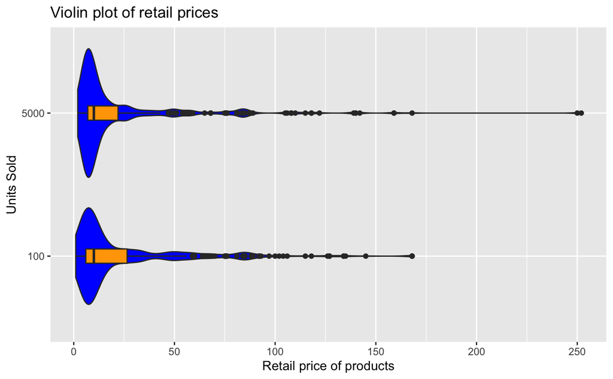

```r
ggplot(data=q1_df, aes(x = units_sold, y = retail_price)) + geom_violin(fill="blue") + geom_boxplot(width = 0.1, fill="orange") + xlab("Units Sold") + ylab("Retail price of products") + ggtitle("Violin plot of retail prices") + coord_flip()
```

3. Creating distribution of bootstrap statistics for the difference in means.

```r
ntrials = 1000
n.sold_100 = favstats(~retail_price|units_sold, data=q1_df)$n[1]
n.sold_5000 = favstats(~retail_price|units_sold, data=q1_df)$n[2]
n.sold_100
```

```
[1] 648
```

```r
n.sold_5000
```

```
[1] 520
```

```r
mean.sold_100 = numeric(ntrials)
mean.sold_5000 = numeric(ntrials)
diffmeanssold = numeric(ntrials)
units_sold_100 = filter(q1_df, units_sold=="100")
units_sold_5000 = filter(q1_df, units_sold=="5000")
```

```r
head(units_sold_100)
```

|  | price | retail_price | units_sold |
| --- | --- | --- | --- |
| 1 | 16.00 | 14 | 100 |
| 2 | 8.00 | 43 | 100 |
| 3 | 2.72 | 3 | 100 |
| 4 | 3.92 | 9 | 100 |
| 5 | 11.00 | 84 | 100 |
| 6 | 6.00 | 8 | 100 |

```r
head(units_sold_5000)
```

|  | price | retail_price | units_sold |
| --- | --- | --- | --- |
| 1 | 8.00 | 22 | 5000 |
| 2 | 8.00 | 8 | 5000 |
| 3 | 7.00 | 6 | 5000 |
| 4 | 5.78 | 22 | 5000 |
| 5 | 2.00 | 2 | 5000 |
| 6 | 11.00 | 10 | 5000 |

```r
for(i in 1:ntrials)
{   mean.sold_100[i] = mean(sample(units_sold_100$retail_price, n.sold_100, replace=TRUE))
    mean.sold_5000[i] = mean(sample(units_sold_5000$retail_price, n.sold_5000, replace=TRUE))
    diffmeanssold[i] = mean.sold_100[i] - mean.sold_5000[i]
}
boot_diffmeanssold = data.frame(mean.sold_100, mean.sold_5000, diffmeanssold)
```

```r
head(boot_diffmeanssold)
```

|  | mean.sold_100 | mean.sold_5000 | diffmeanssold |
| --- | --- | --- | --- |
| 1 | 23.55556 | 21.84231 | 1.7132479 |
| 2 | 23.51235 | 23.69231 | -0.1799620 |
| 3 | 22.46296 | 21.18654 | 1.2764245 |
| 4 | 22.51080 | 22.62308 | -0.1122745 |
| 5 | 24.03858 | 22.12308 | 1.9155033 |
| 6 | 22.63117 | 22.53846 | 0.0927113 |

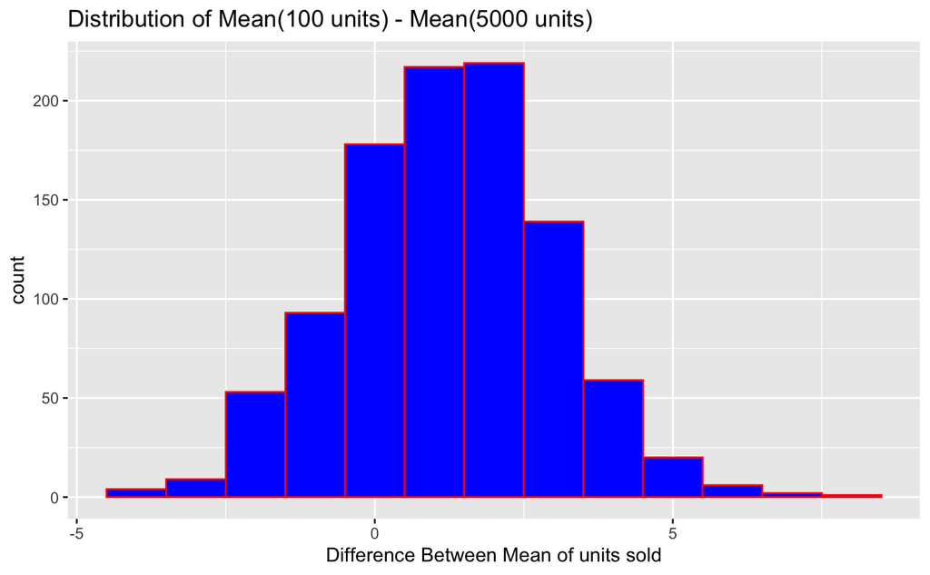

```r
ggplot(data=boot_diffmeanssold, aes(x = diffmeanssold)) + geom_histogram(fill='blue', col='red', binwidth=1) + xlab("Difference Between Mean of units sold") + ggtitle("Distribution of Mean(100 units) - Mean(5000 units)")
```

4. Building 95% confidence interval.

```r
qdata(~ diffmeanssold, c(0.025, 0.975), data=boot_diffmeanssold)
```

```
     2.5%     97.5%
-2.118641  4.565955
```

It can be observed that 0 lies between the confidence interval of -2.1186 - 4.5659.

Since we have significantly more number of sample count, validating our confidence interval using a t-test.

```r
t.test(~retail_price|units_sold, conf.level=0.95, alternative = "two.sided", var.equal=FALSE, q1_df)
```

```
    Welch Two Sample t-test

data:  retail_price by units_sold
t = 0.68137, df = 1069, p-value = 0.4958
alternative hypothesis: true difference in means between group 100 and group 5000 is not equal to 0
95 percent confidence interval:
 -2.277774  4.701230
sample estimates:
 mean in group 100 mean in group 5000
          23.31173           22.10000
```